# Descriptive and univariate analysis

Mathilde Le Vu

2022-07-10

# Characteristics of the population

(variable by variable)

## Year and month of birth

```r
#month of birth
round(prop.table(table(bevn_eco$month))*100,2)
```

```
##
##    1    2    3    4    5    6    7    8    9   10   11   12
## 8.26 7.56 8.21 8.06 8.51 8.42 8.98 8.73 8.77 8.48 7.94 8.07
```

```r
round(prop.table(table(bevn_eco_in7$month))*100,2)
```

```
##
##    1    2    3    4    5    6    7    8    9   10   11   12
## 8.21 7.56 8.22 8.07 8.50 8.43 8.99 8.77 8.79 8.45 7.93 8.08
```

```r
#year of birth
round(prop.table(table(bevn_eco$birthyear))*100,2)
```

```
##
## 2007 2008 2009 2010 2011 2012 2013 2014 2015 2016 2017 2018 2019 2020
## 6.48 6.66 6.79 7.00 6.96 7.12 7.16 7.35 7.44 7.57 7.47 7.48 7.32 7.21
```

```r
round(prop.table(table(bevn_eco_in7$birthyear))*100,2)
```

```
##
## 2007 2008 2009 2010 2011 2012 2013 2014 2015 2016 2017 2018 2019 2020
## 5.85 6.23 6.79 6.99 7.03 7.13 7.19 7.41 7.52 7.63 7.59 7.62 7.51 7.50
```

## State and world region of birth

```r
# State of birth in : Switzerland or Outside of Switzerland
  table(bevn_eco$country_of_birth_cat1, useNA = "always")
```

```
##
##         Switzerland Outside Switzerland                <NA>
##             1202203              124074                   1
```

```r
  round(prop.table(table(bevn_eco$country_of_birth_cat1, useNA="always"))*100,2)
```

```
##
##         Switzerland Outside Switzerland                <NA>
##               90.64                9.36                0.00
```

```r
#State of birth in : Switzerland, Europe, Africa, Americas, Asia, Oceania, other
  table(bevn_eco$country_of_birth_cat2, useNA = "always")
```

```
##
##                         Switz                        Africa                          Asia                        Europe
##                       1202203                          4066                         15109                         75785
##              Northern America                       Oceania Southern and Central America                           <NA>
##                         15183                          4458                          9473                             1
```

```r
  round(prop.table(table(bevn_eco$country_of_birth_cat2, useNA="always"))*100,2)
```

```
##
##                         Switz                        Africa                          Asia                        Europe
##                         90.64                          0.31                          1.14                          5.71
##              Northern America                       Oceania Southern and Central America                           <NA>
##                          1.14                          0.34                          0.71                          0.00
```

```r
#State of birth in : Switzerland, different parts of Europe, other
  round(prop.table(table(bevn_eco$country_of_birth_cat3, useNA="always"))*100,2)
```

```
##
##           Switz  Central Europe  Eastern Europe Northern Europe           other       SE Europe Southern Europe       SW Europe
##           90.64            1.60            0.04            0.17            3.65            0.11            0.65            0.27
##  Western Europe            <NA>
##            2.87            0.00
```

There are **124,074** births that occurred outside of Switzerland.

## Nationality Mother

```r
summary(bevn_eco$mother_nationality)
```

```
##    Min. 1st Qu.  Median    Mean 3rd Qu.    Max.    NA's
##    8100    8100    8100    8174    8231    8998    6053
```

```r
# Nationality of the mother in : Switzerland or Outside of Switzerland
  round(prop.table(table(bevn_eco$mother_nationality_cat1, useNA="always"))*100,2)
```

```
##
##         Switzerland Outside Switzerland                <NA>
##               59.37               40.18                0.46
```

```r
  round(prop.table(table(bevn_eco_in7$mother_nationality_cat1, useNA="always"))*100,2)
```

```
##
##         Switzerland Outside Switzerland                <NA>
##               61.48               38.16                0.36
```

```r
  round(prop.table(table(bevn_eco_in6$mother_nationality_cat1, useNA="always"))*100,2)
```

```
##
##         Switzerland Outside Switzerland                <NA>
##               61.47               38.17                0.36
```

```r
# Nationality of the mother in : Switzerland, Europe, Africa, Northern America, Southern America, Asia, Oceania, other
  round(prop.table(table(bevn_eco$mother_nationality_cat2, useNA="always"))*100,2)
```

```
##
##                         Switz                        Africa                          Asia                        Europe
##                         59.37                          3.05                          3.84                         29.84
##              Northern America                       Oceania                         other Southern and Central America
##                          0.99                          0.21                          0.00                          2.24
##                          <NA>
##                          0.46
```

```r
  round(prop.table(table(bevn_eco_in7$mother_nationality_cat2, useNA="always"))*100,2)
```

```
##
##                         Switz                        Africa                          Asia                        Europe
##                         61.48                          2.88                          3.49                         29.25
##              Northern America                       Oceania                         other Southern and Central America
##                          0.60                          0.11                          0.00                          1.84
##                          <NA>
##                          0.36
```

```r
  round(prop.table(table(bevn_eco_in6$mother_nationality_cat2, useNA="always"))*100,2)
```

```
##
##                         Switz                        Africa                          Asia                        Europe
##                         61.47                          2.88                          3.49                         29.25
##              Northern America                       Oceania                         other Southern and Central America
##                          0.60                          0.11                          0.00                          1.84
##                          <NA>
##                          0.36
```

```r
  table(bevn_eco_in6$mother_nationality_cat2, useNA="always")
```

```
##
##                         Switz                        Africa                          Asia                        Europe
##                        680240                         31891                         38610                        323727
##              Northern America                       Oceania                         other Southern and Central America
##                          6594                          1238                            40                         20317
##                          <NA>
##                          4022
```

```r
#Nationality of the mother in : Switzerland, different parts of Europe, other
  round(prop.table(table(bevn_eco$mother_nationality_cat3, useNA="always"))*100,2)
```

```
##
##           Switz  Central Europe  Eastern Europe Northern Europe           other       SE Europe Southern Europe       SW Europe
##           59.37            7.45            1.02            0.44           10.66            7.67            4.19            4.44
##  Western Europe            <NA>
##            4.30            0.46
```

```r
  round(prop.table(table(bevn_eco_in7$mother_nationality_cat3, useNA="always"))*100,2)
```

```
##
##           Switz  Central Europe  Eastern Europe Northern Europe           other       SE Europe Southern Europe       SW Europe
##           61.48            6.89            0.99            0.39            9.25            8.46            4.29            4.74
##  Western Europe            <NA>
##            3.14            0.36
```

## Place of residence Mother

1-6910 for commune if resident inside Switz  
8201-8703 if resident outside of Switz

```r
#to check minimum and maximum
summary(bevn_eco$com)
```

```
##    Min. 1st Qu.  Median    Mean 3rd Qu.    Max.    NA's
##       1     768    3218    3504    5725    8619    1921
```

```r
head(bevn_eco$com,50)
```

```
##  [1] 1061 6743 1061 6640 6633 6613 6421 4006  246 6158  768 6628 1707 6458 4303  199  415 4208 2422 2767  351 5586 8212 2791 2301
## [26] 4140 4229 2546  700  383 6007 2701 1065  243 6643 3340  100  177  194  198  172  261 1008  158   90 1707  261 1061 4165 6771
```

```r
# Place of residence of the mother in : inside or outside Switzerland
  round(prop.table(table(bevn_eco$mother_residence_cat1, useNA="always"))*100,2)
```

```
##
##         Switzerland Outside Switzerland                <NA>
##               88.75               11.10                0.14
```

```r
  table(bevn_eco$mother_residence_cat1, useNA="always")
```

```
##
##         Switzerland Outside Switzerland                <NA>
##             1177097              147260                1921
```

## Status of Residence of the mother

1=permanent resident, 2=non-permanent resident, 4=short stay, 9=domiciled abroad

```r
summary(bevn_eco$resident_status)
```

```
##    Min. 1st Qu.  Median    Mean 3rd Qu.    Max.
##   1.000   1.000   1.000   1.908   1.000   9.000
```

```r
table(bevn_eco$resident_status, useNA = "always")
```

```
##
##       1       2       4       9    <NA>
## 1167672    8411    1014  149181       0
```

```r
round(prop.table(table(bevn_eco$resident_status, useNA="always"))*100,2)
```

```
##
##     1     2     4     9  <NA>
## 88.04  0.63  0.08 11.25  0.00
```

```r
table(bevn_eco$mother_nationality_cat1, bevn_eco$resident_status)
```

```
##
##                            1      2      4      9
##   Switzerland         716339      6      0  71002
##   Outside Switzerland 447156   6849   1013  77860
```

## Nationality father

See separate codebook. Expected: 8100-8703

```r
# categorizing nationality of the father in : inside or outside Switzerland
  round(prop.table(table(bevn_eco$father_nationality_cat1, useNA="always"))*100,2)
```

```
##
##         Switzerland Outside Switzerland                <NA>
##               58.20               39.56                2.24
```

```r
  table(bevn_eco$father_nationality_cat1, useNA="always")
```

```
##
##         Switzerland Outside Switzerland                <NA>
##              771897              524637               29744
```

```r
  round(prop.table(table(bevn_eco_in7$father_nationality_cat1, useNA="always"))*100,2)
```

```
##
##         Switzerland Outside Switzerland                <NA>
##               60.47               37.81                1.72
```

```r
  table(bevn_eco_in7$father_nationality_cat1, useNA="always")
```

```
##
##         Switzerland Outside Switzerland                <NA>
##              667207              417218               18927
```

## lebend geboren oder nicht = born alive or not

1=lifeborn, 2=stillborn

```r
table(bevn_eco$stillbirth, useNA = "always")
```

```
##
##       0       1    <NA>
## 1321060    5218       0
```

```r
round(prop.table(table(bevn_eco$stillbirth, useNA="always"))*100,3)
```

```
##
##      0      1   <NA>
## 99.607  0.393  0.000
```

```r
round(prop.table(table(bevn_eco_in6$stillbirth, useNA="always"))*100,3)
```

```
##
##      0      1   <NA>
## 99.699  0.301  0.000
```

## Sex

```r
table(bevn_eco$sex, useNA = "always")
```

```
##
##      1      2   <NA>
## 681503 644775      0
```

```r
round(prop.table(table(bevn_eco$sex, useNA="always"))*100,3)
```

```
##
##      1      2   <NA>
## 51.385 48.615  0.000
```

```r
table(bevn_eco_in7$sex, useNA = "always")
```

```
##
##      1      2   <NA>
## 567645 535707      0
```

```r
round(prop.table(table(bevn_eco_in7$sex, useNA="always"))*100,3)
```

```
##
##      1      2   <NA>
## 51.447 48.553  0.000
```

## Gestational age

```r
## GA in weeks
summary(bevn_eco$GA_weeks)
```

```
##    Min. 1st Qu.  Median    Mean 3rd Qu.    Max.    NA's
##   16.00   38.57   39.57   39.22   40.43   45.86  138581
```

```r
summary(bevn_eco_in7$GA_weeks)
```

```
##    Min. 1st Qu.  Median    Mean 3rd Qu.    Max.
##   22.14   38.71   39.57   39.41   40.43   45.86
```

## Length at birth (cm)

```r
summary(bevn_eco$BL)
```

```
##    Min. 1st Qu.  Median    Mean 3rd Qu.    Max.    NA's
##    1.00   48.00   50.00   49.31   51.00   64.00  124295
```

```r
table(bevn_eco$BL, useNA = "always")
```

```
##
##      1      5      8      9     10     11     12     13     14     15     16     17     18     19     20     21     22     23
##      2      1      1      1      6      4      2      2      2     21     15     26     50     44    102     84    126    136
##     24     25     26     27     28     29     30     31     32     33     34     35     36     37     38     39     40     41
##    181    239    333    439    564    556    785    710    793    825    884    959   1052   1175   1460   1720   2624   3449
##     42     43     44     45     46     47     48     49     50     51     52     53     54     55     56     57     58     59
##   5450   8545  14849  27706  52684  96281 152658 193518 236018 175481 116488  59628  27437  10078   3976   1215    391    147
##     60     61     62     63     64   <NA>
##     45      7      3      4      1 124295
```

```r
summary(bevn_eco_in7$BL)
```

```
##    Min. 1st Qu.  Median    Mean 3rd Qu.    Max.
##   20.00   48.00   50.00   49.54   51.00   64.00
```

## Weight at birth (g)

```r
summary(bevn_eco$BW)
```

```
##    Min. 1st Qu.  Median    Mean 3rd Qu.    Max.    NA's
##       3    3000    3320    3285    3640    9351  124331
```

```r
summary(bevn_eco_in7$BW)
```

```
##    Min. 1st Qu.  Median    Mean 3rd Qu.    Max.
##     502    3040    3350    3332    3650    9351
```

```r
#BW categ. in LBW (<2500g) or not (>2500)
table(bevn_eco$LBW, useNA="always")
```

```
##
##       0       1    <NA>
## 1120677   81270  124331
```

```r
round(prop.table(table(bevn_eco$LBW, useNA="always"))*100, 3)
```

```
##
##      0      1   <NA>
## 84.498  6.128  9.374
```

```r
table(bevn_eco_in7$LBW, useNA="always")
```

```
##
##       0       1    <NA>
## 1054225   49127       0
```

```r
round(prop.table(table(bevn_eco_in7$LBW, useNA="always"))*100, 3)
```

```
##
##      0      1   <NA>
## 95.547  4.453  0.000
```

## Number of babies

1=singleton, 2=twins, 3=triplets, …, 6=sextuplets and more

```r
table(bevn_eco$nb_of_babies, useNA="always")
```

```
##
##       1       2       3       4       5    <NA>
## 1278139   46836    1266      32       5       0
```

```r
round(prop.table(table(bevn_eco$nb_of_babies, useNA="always"))*100,2)
```

```
##
##     1     2     3     4     5  <NA>
## 96.37  3.53  0.10  0.00  0.00  0.00
```

```r
##Single VS multiple pregnancies
table(bevn_eco$singleton_or_multiple)
```

```
##
## singleton  multiple
##   1278139     48139
```

```r
round(prop.table(table(bevn_eco$singleton_or_multiple, useNA="always"))*100,2)
```

```
##
## singleton  multiple      <NA>
##     96.37      3.63      0.00
```

```r
round(prop.table(table(bevn_eco_in7$singleton_or_multiple, useNA="always"))*100,2)
```

```
##
## singleton  multiple      <NA>
##       100         0         0
```

## Parity

```r
table(bevn_eco$parity_cat, useNA = "always")
```

```
##
##  (0,1]  (1,2]  (2,3] (3,20]   <NA>
## 647597 478533 147555  47350   5243
```

```r
round(prop.table(table(bevn_eco$parity_cat, useNA="always"))*100,2)
```

```
##
##  (0,1]  (1,2]  (2,3] (3,20]   <NA>
##  48.83  36.08  11.13   3.57   0.40
```

```r
table(bevn_eco_in7$parity_cat, useNA = "always")
```

```
##
##  (0,1]  (1,2]  (2,3] (3,20]   <NA>
## 545420 402374 121031  34527      0
```

```r
round(prop.table(table(bevn_eco_in7$parity_cat, useNA="always"))*100,2)
```

```
##
##  (0,1]  (1,2]  (2,3] (3,20]   <NA>
##  49.43  36.47  10.97   3.13   0.00
```

## Maternal and paternal age

```r
summary(bevn_eco$mat_age)
```

```
##    Min. 1st Qu.  Median    Mean 3rd Qu.    Max.
##   11.00   28.00   32.00   31.47   35.00   67.00
```

```r
summary(bevn_eco_in7$mat_age)
```

```
##    Min. 1st Qu.  Median    Mean 3rd Qu.    Max.
##   12.00   28.00   31.00   31.35   35.00   50.00
```

```r
round(prop.table(table(bevn_eco_in7$mat_age_cat))*100,2)
```

```
##
## (25,30] (10,20] (20,25] (30,35] (35,40] (40,70]
##   27.89    1.17    9.79   37.41   19.94    3.80
```

```r
summary(bevn_eco$pat_age)
```

```
##    Min. 1st Qu.  Median    Mean 3rd Qu.    Max.    NA's
##   13.00   30.00   34.00   34.58   38.00   93.00   25964
```

```r
summary(bevn_eco_in7$pat_age)
```

```
##    Min. 1st Qu.  Median    Mean 3rd Qu.    Max.    NA's
##   13.00   30.00   34.00   34.41   38.00   93.00   15925
```

```r
 table(bevn_eco_in7$pat_age_cat, useNA = "always")
```

```
##
##  (10,20]  (20,30]  (30,40]  (40,50]  (50,70] (70,100]     <NA>
##     3298   251805   655613   159964    16566      181    15925
```

```r
 round(prop.table(table(bevn_eco_in7$pat_age_cat))*100,2)
```

```
##
##  (10,20]  (20,30]  (30,40]  (40,50]  (50,70] (70,100]
##     0.30    23.16    60.29    14.71     1.52     0.02
```

## Age difference between parents

```r
summary(bevn_eco_in7$parent_age_diff)
```

```
##    Min. 1st Qu.  Median    Mean 3rd Qu.    Max.    NA's
## -31.000   0.000   2.000   3.028   5.000  54.000   15925
```

# Ecological variables

## Language

```r
  table(bevn_eco$Language,  useNA="always")
```

```
##
## German or Romansh            French           Italian              <NA>
##            832798            303001             41298            149181
```

```r
  round(prop.table(table(bevn_eco$Language,  useNA="always"))*100,2)
```

```
##
## German or Romansh            French           Italian              <NA>
##             62.79             22.85              3.11             11.25
```

```r
  table(bevn_eco_in7$Language,  useNA="always")
```

```
##
## German or Romansh            French           Italian              <NA>
##            789066            274889             39397                 0
```

```r
  round(prop.table(table(bevn_eco_in7$Language,  useNA="always"))*100,2)
```

```
##
## German or Romansh            French           Italian              <NA>
##             71.52             24.91              3.57              0.00
```

## Urban variables

1 is urban, 0 is rural

```r
 table(bevn_eco$Urban3)
```

```
##
##      0      1
## 591925 585172
```

```r
 round(prop.table(table(bevn_eco$Urban3,  useNA="always"))*100,2)
```

```
##
##     0     1  <NA>
## 44.63 44.12 11.25
```

```r
round(prop.table(table(bevn_eco_in7$Urban3,  useNA="always"))*100,2)
```

```
##
##     0     1  <NA>
## 50.61 49.39  0.00
```

## Grossregion

```r
table(bevn_eco$Grossregion)
```

```
##
##      1      2      3      4      5      6      7
## 234952 251387 154254 226278 157619 112909  39698
```

```r
round(prop.table(table(bevn_eco$Grossregion,  useNA="always"))*100,2)
```

```
##
##     1     2     3     4     5     6     7  <NA>
## 17.72 18.95 11.63 17.06 11.88  8.51  2.99 11.25
```

```r
round(prop.table(table(bevn_eco_in7$Grossregion,  useNA="always"))*100,2)
```

```
##
##     1     2     3     4     5     6     7  <NA>
## 19.32 21.36 13.22 19.37 13.57  9.72  3.43  0.00
```

## Altitude

```r
summary(bevn_eco$mean_Alt_mean2)
```

```
##    Min. 1st Qu.  Median    Mean 3rd Qu.    Max.    NA's
##   208.2   428.6   481.3   537.2   595.8  1941.2  149181
```

```r
summary(bevn_eco_in7$mean_Alt_mean2)
```

```
##    Min. 1st Qu.  Median    Mean 3rd Qu.    Max.
##   208.2   429.2   481.9   537.2   595.8  1941.2
```

```r
summary(bevn_eco_in6$mean_Alt_mean2)
```

```
##    Min. 1st Qu.  Median    Mean 3rd Qu.    Max.
##   208.2   429.2   481.9   537.2   595.8  1941.2
```

## SSEP

```r
summary(bevn_eco$mean_ssep2)
```

```
##    Min. 1st Qu.  Median    Mean 3rd Qu.    Max.    NA's
##   23.63   52.02   58.64   58.16   64.28   86.68  149181
```

```r
summary(bevn_eco_in7$mean_ssep2)
```

```
##    Min. 1st Qu.  Median    Mean 3rd Qu.    Max.
##   23.63   52.02   58.57   58.16   64.32   86.68
```

```r
summary(bevn_eco_in6$mean_ssep2)
```

```
##    Min. 1st Qu.  Median    Mean 3rd Qu.    Max.
##   23.63   52.02   58.57   58.15   64.32   86.68
```

# Simple tables: variables through the year

## Gestational age through the years

```r
#calculating median by year
 GA_median <- aggregate(GA_weeks ~ birthyear, data = bevn_eco_in7, median) # from 2006 it was systematically collected
 GA_median
```

```
##    birthyear GA_weeks
## 1       2007 39.57143
## 2       2008 39.57143
## 3       2009 39.57143
## 4       2010 39.57143
## 5       2011 39.57143
## 6       2012 39.57143
## 7       2013 39.57143
## 8       2014 39.57143
## 9       2015 39.57143
## 10      2016 39.57143
## 11      2017 39.71429
## 12      2018 39.71429
## 13      2019 39.71429
## 14      2020 39.71429
```

```r
#same but using tidyverse
 gamedian <- bevn_eco_in7 %>%
   group_by(birthyear) %>%
     filter( !is.na(GA_weeks)) %>%
   summarise(medGA=format(median(GA_weeks),digits=5))
ungroup(gamedian)
```

```
## # A tibble: 14 x 2
##    birthyear medGA
##        <int> <chr>
##  1      2007 39.571
##  2      2008 39.571
##  3      2009 39.571
##  4      2010 39.571
##  5      2011 39.571
##  6      2012 39.571
##  7      2013 39.571
##  8      2014 39.571
##  9      2015 39.571
## 10      2016 39.571
## 11      2017 39.714
## 12      2018 39.714
## 13      2019 39.714
## 14      2020 39.714
```

```r
# Calculate the GA mode through the years
ga_mode <- bevn_eco_in7 %>%
   group_by(birthyear) %>%
     filter( !is.na(GA_weeks)) %>%
   summarise(mode=format(getmode(GA_weeks), digits=7))
ungroup(ga_mode)
```

```
## # A tibble: 14 x 2
##    birthyear mode
##        <int> <chr>
##  1      2007 40
##  2      2008 40
##  3      2009 40.14286
##  4      2010 40
##  5      2011 40.14286
##  6      2012 40
##  7      2013 40.14286
##  8      2014 40.14286
##  9      2015 40.14286
## 10      2016 40.14286
## 11      2017 40.14286
## 12      2018 40.14286
## 13      2019 40.14286
## 14      2020 40.14286
```

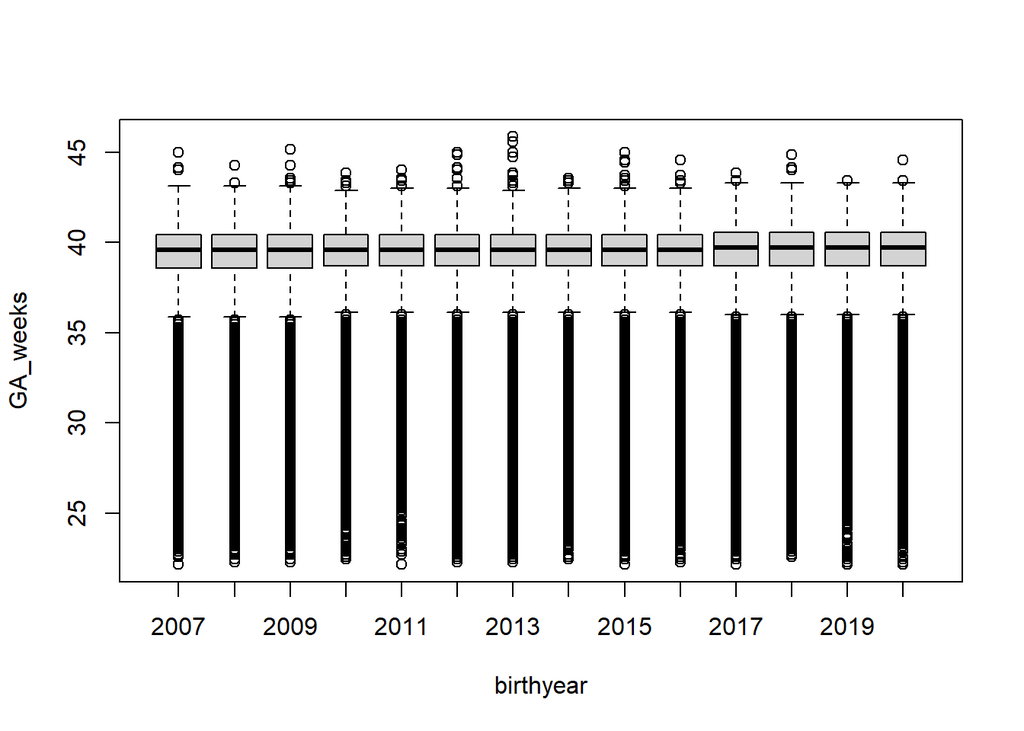

```r
## GA frequency tables through the years
boxplot(GA_weeks ~birthyear, data=bevn_eco_in7)
```

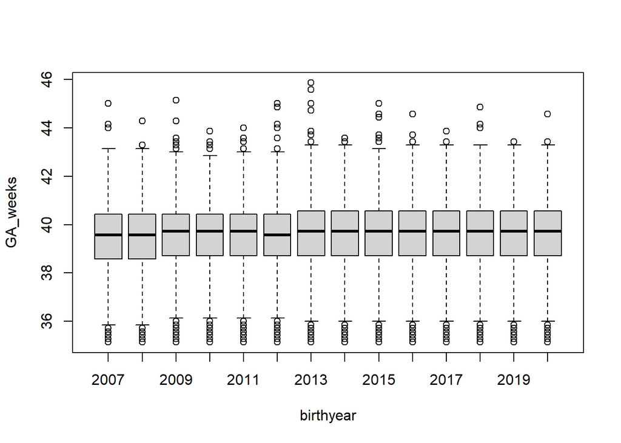

```r
  #subset with GA over 35 weeks
  boxplot(GA_weeks ~birthyear, data=bevn_eco_in7, subset = GA_weeks>35)
```

## Mother nationality through the years

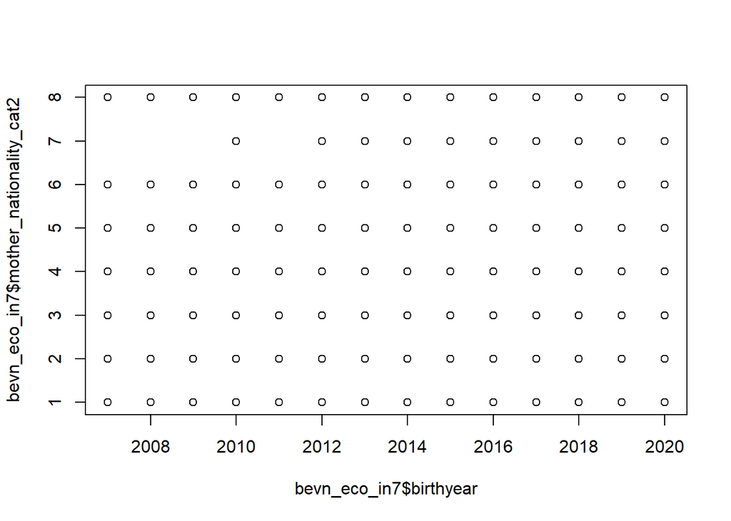

```r
plot(bevn_eco_in7$birthyear, bevn_eco_in7$mother_nationality_cat2)
```

```r
tabb <- round(prop.table(table(bevn_eco_in7$mother_nationality_cat2, bevn_eco_in7$birthyear), margin=2)*100,2)
tabb
```

```
##
##                                  2007  2008  2009  2010  2011  2012  2013  2014  2015  2016  2017  2018  2019  2020
##   Switz                         65.15 64.96 64.03 63.17 62.59 61.98 61.71 60.95 60.49 59.77 59.83 60.17 60.14 60.65
##   Africa                         1.66  1.79  2.17  2.15  2.70  2.80  3.05  2.93  3.17  3.48  3.67  3.48  3.46  3.29
##   Asia                           3.36  3.12  3.05  3.00  3.14  3.32  3.23  3.45  3.51  4.04  3.92  3.92  3.83  3.86
##   Europe                        27.25 27.51 27.88 28.83 28.83 29.04 29.37 30.11 30.21 30.29 30.21 30.11 30.30 29.99
##   Northern America               0.54  0.61  0.66  0.64  0.61  0.68  0.59  0.64  0.64  0.54  0.57  0.59  0.53  0.57
##   Oceania                        0.15  0.10  0.12  0.12  0.13  0.15  0.11  0.12  0.12  0.11  0.09  0.09  0.09  0.10
##   other                          0.00  0.00  0.00  0.00  0.00  0.00  0.00  0.00  0.00  0.01  0.00  0.01  0.01  0.01
##   Southern and Central America   1.88  1.92  2.08  2.08  2.01  2.02  1.94  1.81  1.86  1.75  1.70  1.64  1.65  1.53
```

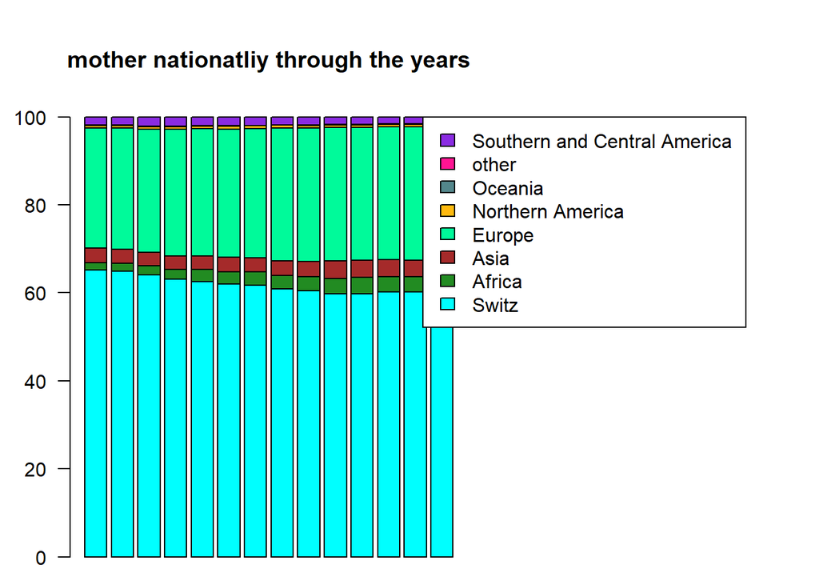

```r
par(mar=c(1,3,5,15))
barplot (tabb, las=2, cex.names=.9, legend.text=TRUE, main="mother nationatliy through the years", col= c("cyan", "forestgreen", "brown", "mediumspringgreen", "darkgoldenrod1", "cadetblue4", "deeppink", "blueviolet", "gray66"), args.legend=list(x="topright", inset=c(-0.7, 0)))
```

## Birthweight through time

```r
#birthweight through the years
BW_median2 <- aggregate(BW ~ birthyear, data = bevn_eco_in7, median)
BW_median2
```

```
##    birthyear   BW
## 1       2007 3350
## 2       2008 3350
## 3       2009 3340
## 4       2010 3350
## 5       2011 3350
## 6       2012 3350
## 7       2013 3340
## 8       2014 3340
## 9       2015 3345
## 10      2016 3340
## 11      2017 3350
## 12      2018 3340
## 13      2019 3350
## 14      2020 3360
```

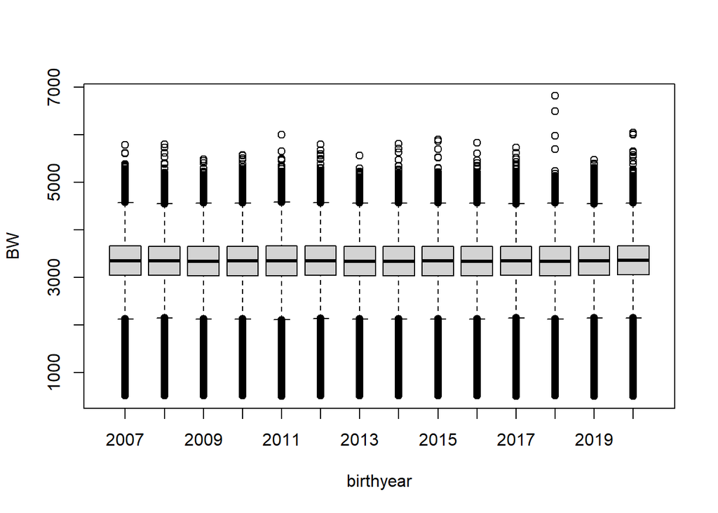

```r
boxplot(BW~birthyear, data=bevn_eco_in7, subset= BW<8000)
```

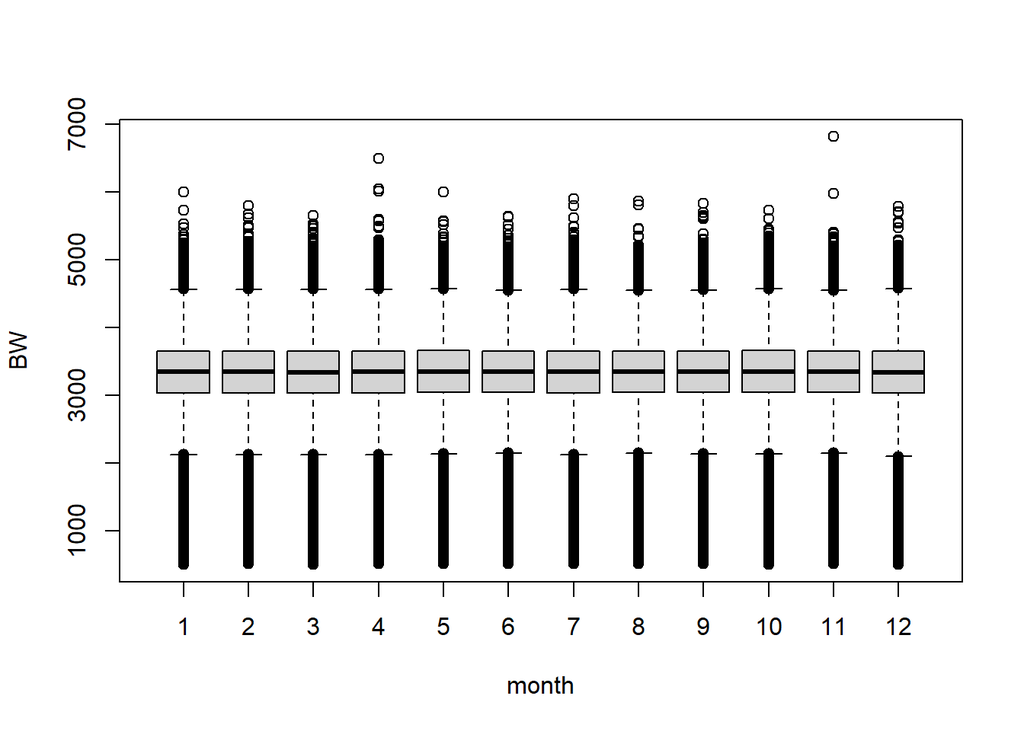

```r
#birthweight by month
boxplot(BW~month, data=bevn_eco_in7, subset= BW<8000)
```

## Birth length through the years

```r
BL_median <- aggregate(BL ~ birthyear, data = bevn_eco_in7, median)
BL_median
```

```
##    birthyear BL
## 1       2007 50
## 2       2008 50
## 3       2009 50
## 4       2010 50
## 5       2011 50
## 6       2012 50
## 7       2013 50
## 8       2014 50
## 9       2015 50
## 10      2016 50
## 11      2017 50
## 12      2018 50
## 13      2019 50
## 14      2020 50
```

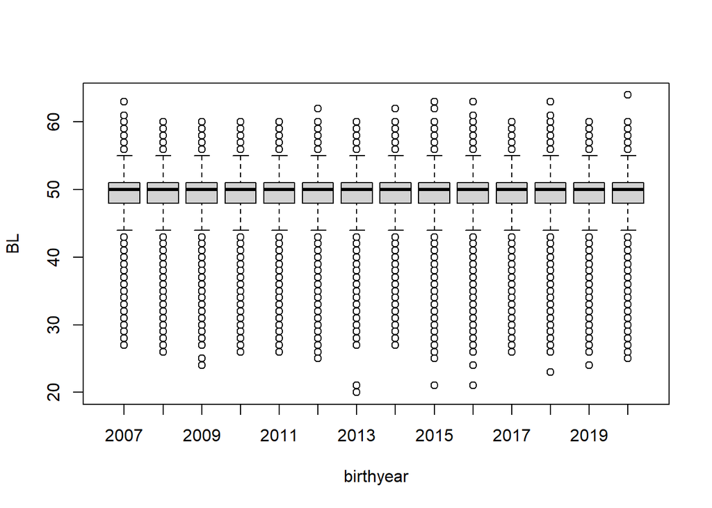

```r
boxplot(BL~birthyear, data=bevn_eco_in7)
```

Birthlength median is robustly consistent at 50cm, 2007-2020.

## Sex % through the years

```r
table(bevn_eco_in7$sex, bevn_eco_in7$birthyear)
```

```
##
##      2007  2008  2009  2010  2011  2012  2013  2014  2015  2016  2017  2018  2019  2020
##   1 33099 35470 38676 39534 39935 40718 40807 42088 42873 43095 43053 43128 42470 42699
##   2 31444 33311 36259 37559 37639 37994 38473 39644 40139 41142 40657 40958 40429 40059
```

```r
round(prop.table(table(bevn_eco_in7$sex, bevn_eco_in7$birthyear), margin=2)*100,2)
```

```
##
##      2007  2008  2009  2010  2011  2012  2013  2014  2015  2016  2017  2018  2019  2020
##   1 51.28 51.57 51.61 51.28 51.48 51.73 51.47 51.50 51.65 51.16 51.43 51.29 51.23 51.60
##   2 48.72 48.43 48.39 48.72 48.52 48.27 48.53 48.50 48.35 48.84 48.57 48.71 48.77 48.40
```

## Stillbirth % through the years, their median/mode GA and BW

### Gestational age of stillborn babies

```r
table(bevn_eco_in6$stillbirth, bevn_eco_in6$birthyear, useNA="always")
```

```
##
##         2007  2008  2009  2010  2011  2012  2013  2014  2015  2016  2017  2018  2019  2020  <NA>
##   0    64543 68781 74935 77093 77574 78712 79280 81732 83012 84237 83710 84086 82899 82758     0
##   1      183   230   237   215   241   230   257   259   242   252   263   264   229   225     0
##   <NA>     0     0     0     0     0     0     0     0     0     0     0     0     0     0     0
```

```r
round(prop.table(table(bevn_eco_in6$stillbirth, bevn_eco_in6$birthyear), margin=2)*100,3)
```

```
##
##       2007   2008   2009   2010   2011   2012   2013   2014   2015   2016   2017   2018   2019   2020
##   0 99.717 99.667 99.685 99.722 99.690 99.709 99.677 99.684 99.709 99.702 99.687 99.687 99.725 99.729
##   1  0.283  0.333  0.315  0.278  0.310  0.291  0.323  0.316  0.291  0.298  0.313  0.313  0.275  0.271
```

```r
#calculating median GA by year of birth, for stillborn, with tidyverse
  GA_SB_Y <- bevn_eco_in6 %>%
  group_by(birthyear) %>%
  filter(stillbirth==1) %>%
   filter(!is.na(GA_weeks)) %>%
    summarise(medGA=format(median(GA_weeks),digits=5))
  ungroup(GA_SB_Y)
```

```
## # A tibble: 14 x 2
##    birthyear medGA
##        <int> <chr>
##  1      2007 33.714
##  2      2008 33.571
##  3      2009 33.143
##  4      2010 32.286
##  5      2011 33.286
##  6      2012 32.357
##  7      2013 32.571
##  8      2014 33.286
##  9      2015 32.929
## 10      2016 34.357
## 11      2017 31.143
## 12      2018 32.429
## 13      2019 34
## 14      2020 33.571
```

```r
#calculating mode GA by year of birth, for stillborn
  ga_y_mode <- bevn_eco_in6 %>%
   group_by(birthyear) %>%
     filter( !is.na(GA_weeks)) %>%
     filter(stillbirth==1) %>%
   summarise(mode=format(getmode(GA_weeks), digits=5))
  ungroup(ga_y_mode)
```

```
## # A tibble: 14 x 2
##    birthyear mode
##        <int> <chr>
##  1      2007 38.143
##  2      2008 23.571
##  3      2009 23.286
##  4      2010 23.429
##  5      2011 23.571
##  6      2012 23.286
##  7      2013 24
##  8      2014 23.143
##  9      2015 39.571
## 10      2016 38.571
## 11      2017 38
## 12      2018 22.714
## 13      2019 37.571
## 14      2020 36.286
```

```r
#GA categrory for stillbirths
 GA_SB <- bevn_eco_in6 %>%
     filter(stillbirth==1)
  table(GA_SB$GA_weeks_cat)
```

```
##
## [16,24] (24,30] (30,34] (34,39] (39,44] (44,46]
##     484     803     528    1022     490       0
```

```r
  round(prop.table(table(GA_SB$GA_weeks_cat))*100,2)
```

```
##
## [16,24] (24,30] (30,34] (34,39] (39,44] (44,46]
##   14.55   24.14   15.87   30.72   14.73    0.00
```

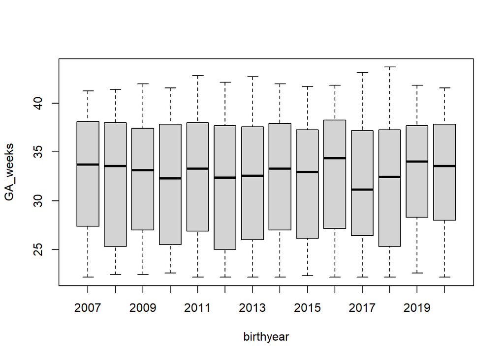

```r
#GA frequency for stillbirths, through the years
  boxplot(GA_weeks~birthyear, data=GA_SB)
```

### Birthweight of stillborn babies

```r
 #calculating median BW for stillborn babies, by year
  BW_median_sb <- aggregate(BW ~ birthyear, data = subset(bevn_eco_in6, stillbirth==1), median)
  BW_median_sb
```

```
##    birthyear   BW
## 1       2007 1920
## 2       2008 1735
## 3       2009 1590
## 4       2010 1580
## 5       2011 1740
## 6       2012 1590
## 7       2013 1650
## 8       2014 1730
## 9       2015 1645
## 10      2016 2070
## 11      2017 1500
## 12      2018 1560
## 13      2019 1900
## 14      2020 1860
```

```r
 #calculating mode BW for stillborn babies, by year
  BW_y_mode <- bevn_eco_in6 %>%
   group_by(birthyear) %>%
     filter( !is.na(BW)) %>%
     filter(stillbirth==1) %>%
   summarise(mode=format(getmode(BW), digits=5))
  ungroup(BW_y_mode)
```

```
## # A tibble: 14 x 2
##    birthyear mode
##        <int> <chr>
##  1      2007 1920
##  2      2008 600
##  3      2009 510
##  4      2010 570
##  5      2011 580
##  6      2012 700
##  7      2013 730
##  8      2014 2500
##  9      2015 520
## 10      2016 520
## 11      2017 540
## 12      2018 530
## 13      2019 2770
## 14      2020 650
```

```r
  #BW frequency for stillbirths, through the years
  BW_SB_Y_freq <- bevn_eco_in6 %>%
   group_by(birthyear) %>%
  filter(stillbirth==1) %>%
   filter(!is.na(BW))

 round(prop.table(table(BW_SB_Y_freq$LBW,BW_SB_Y_freq$birthyear), margin=2)*100,2)
```

```
##
##      2007  2008  2009  2010  2011  2012  2013  2014  2015  2016  2017  2018  2019  2020
##   0 37.16 32.61 32.91 29.30 33.20 30.87 27.63 31.66 29.34 34.92 27.00 25.00 34.50 33.78
##   1 62.84 67.39 67.09 70.70 66.80 69.13 72.37 68.34 70.66 65.08 73.00 75.00 65.50 66.22
```

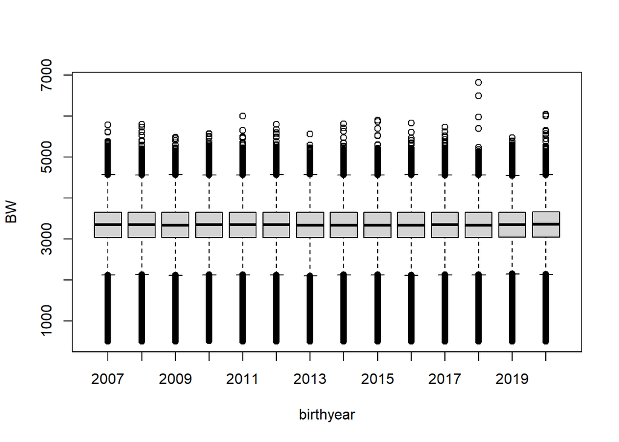

```r
 boxplot(BW~birthyear, data=bevn_eco_in6, subset=BW<8000)
```

## Maternal age through the years

```r
AM_median <- aggregate(mat_age ~ birthyear, data = bevn_eco_in7, median)
AM_median
```

```
##    birthyear mat_age
## 1       2007      31
## 2       2008      31
## 3       2009      31
## 4       2010      31
## 5       2011      31
## 6       2012      31
## 7       2013      31
## 8       2014      31
## 9       2015      32
## 10      2016      32
## 11      2017      32
## 12      2018      32
## 13      2019      32
## 14      2020      32
```

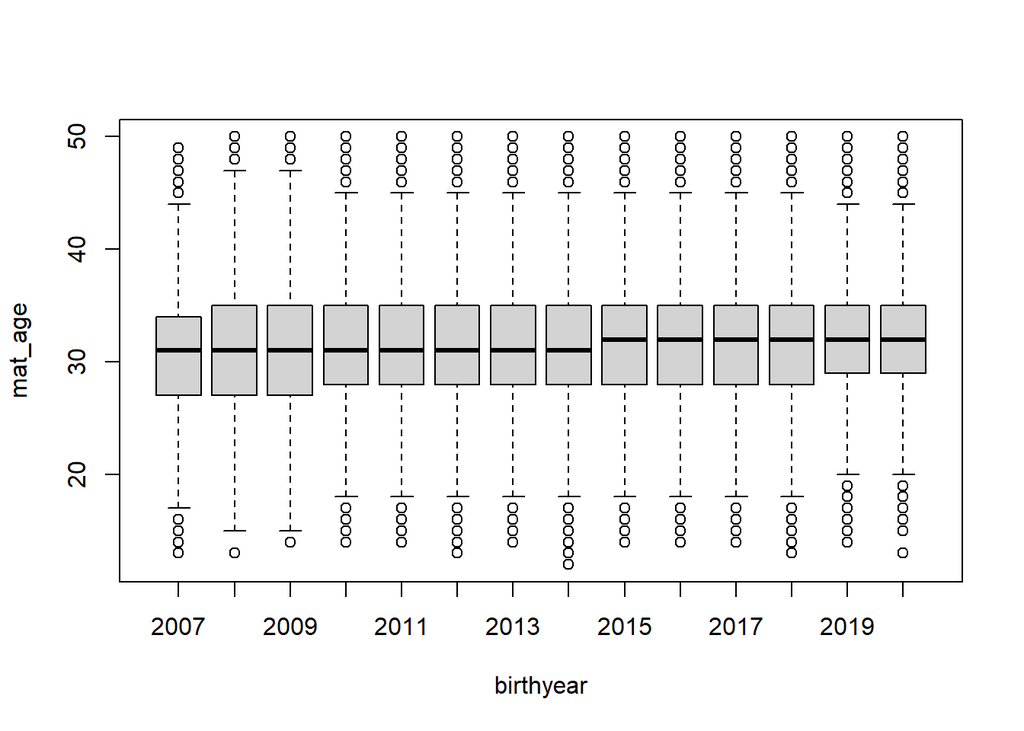

```r
boxplot(mat_age~birthyear, data=bevn_eco_in7)
```

## Age difference between parents, through the years

```r
summary(bevn_eco_in7$parent_age_diff)
```

```
##    Min. 1st Qu.  Median    Mean 3rd Qu.    Max.    NA's
## -31.000   0.000   2.000   3.028   5.000  54.000   15925
```

```r
agediff_y <- aggregate(parent_age_diff ~ birthyear, data = bevn_eco_in7, median)
agediff_y
```

```
##    birthyear parent_age_diff
## 1       2007               3
## 2       2008               2
## 3       2009               2
## 4       2010               2
## 5       2011               2
## 6       2012               2
## 7       2013               2
## 8       2014               2
## 9       2015               2
## 10      2016               2
## 11      2017               2
## 12      2018               2
## 13      2019               2
## 14      2020               2
```

## Time variables

I created two variables for date : one combining month+year only, and another combining day+month+year. I set up day to 1st of each month in order to have variable m-d-y, easier to work with.

```r
#month year
  tail(bevn_eco_in7$birth_Y_M)
```

```
## [1] 2020-12 2020-12 2020-12 2020-12 2020-12 2020-12
## 168 Levels: 2007-01 2007-02 2007-03 2007-04 2007-05 2007-06 2007-07 2007-08 2007-09 2007-10 2007-11 2007-12 2008-01 ... 2020-12
```

```r
  head(bevn_eco_in7$birth_Y_M)
```

```
## [1] 2007-01 2007-01 2007-01 2007-01 2007-01 2007-01
## 168 Levels: 2007-01 2007-02 2007-03 2007-04 2007-05 2007-06 2007-07 2007-08 2007-09 2007-10 2007-11 2007-12 2008-01 ... 2020-12
```

```r
  #day month year
  summary(bevn_eco_in7$birth_Y_M_1stday)
```

```
##         Min.      1st Qu.       Median         Mean      3rd Qu.         Max.
## "2007-01-01" "2010-11-01" "2014-05-01" "2014-03-21" "2017-09-01" "2020-12-01"
```

```r
  tail(bevn_eco_in7$birth_Y_M_1stday)
```

```
## [1] "2020-12-01" "2020-12-01" "2020-12-01" "2020-12-01" "2020-12-01" "2020-12-01"
```

```r
  head(bevn_eco_in7$birth_Y_M_1stday)
```

```
## [1] "2007-01-01" "2007-01-01" "2007-01-01" "2007-01-01" "2007-01-01" "2007-01-01"
```

# Simple plots

## BW or BL depending on GA

Too different sets with either all birthweights/GA or birtsweights “normal” (100;8000) and GA >20 weeks and with either all birthlengths or “normal” birthlengths (10,6)[ and GA >20 weeks.

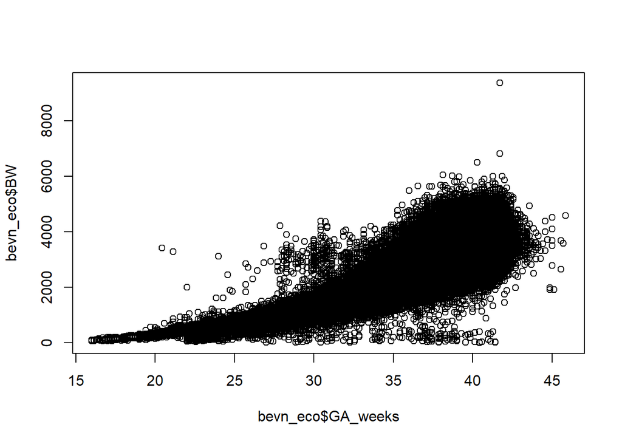

```r
plot(bevn_eco$GA_weeks,bevn_eco$BW)
```

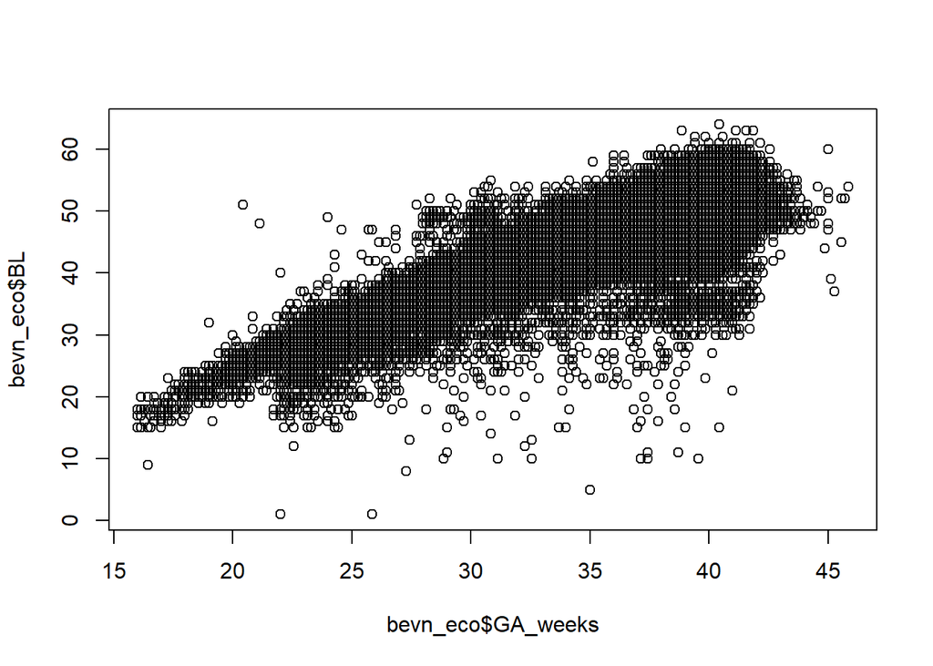

```r
#BW and GA, all birthweights
plot(bevn_eco$GA_weeks, bevn_eco$BL)
```

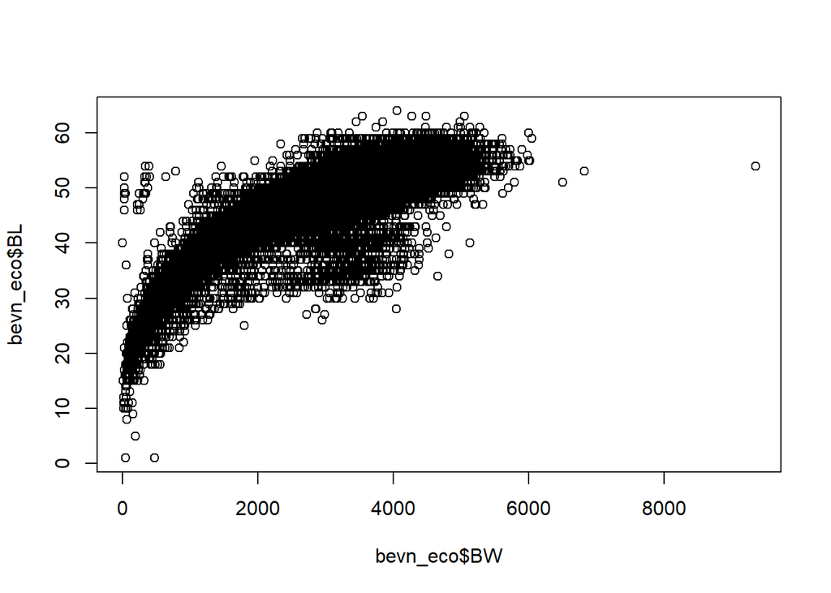

```r
#BL and GA, all birthlengths
plot(bevn_eco$BW, bevn_eco$BL)
```

```r
#BW and BL, all
```

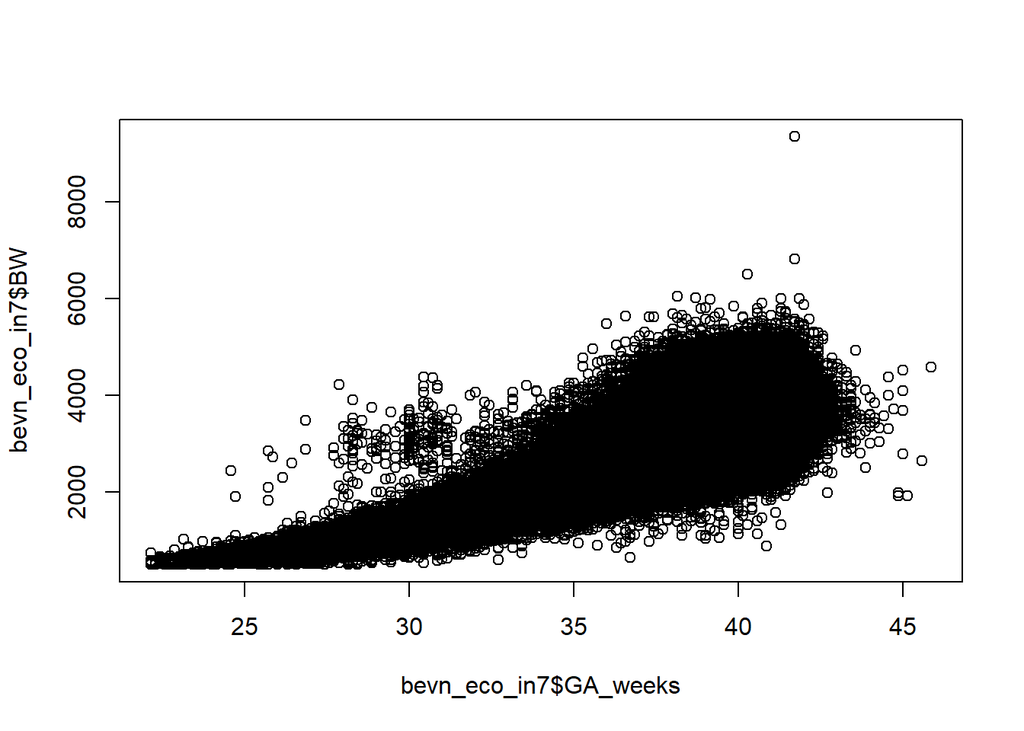

```r
#with data set bevn_eco_in7
plot(bevn_eco_in7$GA_weeks, bevn_eco_in7$BW)
```

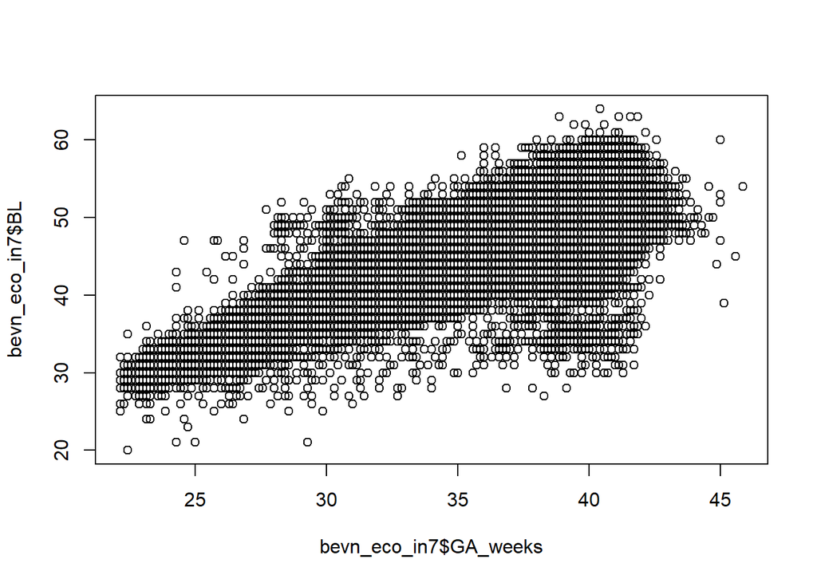

```r
plot(bevn_eco_in7$GA_weeks, bevn_eco_in7$BL)
```

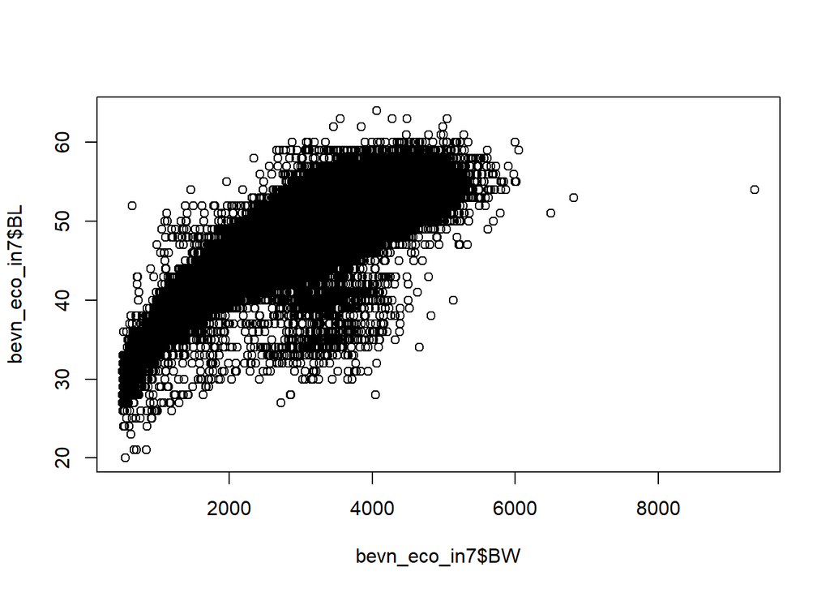

```r
plot(bevn_eco_in7$BW,bevn_eco_in7$BL)
```

# UNIVARIATE ANALYSIS

## BIRTHWEIGHT

### Birthweight change through the years: Simple model

```r
m_BW_years <- lm(BW~birthyear, data=bevn_eco_in7)
summary(m_BW_years)
```

```
##
## Call:
## lm(formula = BW ~ birthyear, data = bevn_eco_in7)
##
## Residuals:
##     Min      1Q  Median      3Q     Max
## -2829.7  -291.2    16.4   318.3  6017.4
##
## Coefficients:
##              Estimate Std. Error t value Pr(>|t|)
## (Intercept) 2793.8696   244.0660  11.447   <2e-16 ***
## birthyear      0.2674     0.1212   2.207   0.0273 *
## ---
## Signif. codes:  0 '***' 0.001 '**' 0.01 '*' 0.05 '.' 0.1 ' ' 1
##
## Residual standard error: 504.7 on 1103350 degrees of freedom
## Multiple R-squared:  4.413e-06,  Adjusted R-squared:  3.507e-06
## F-statistic:  4.87 on 1 and 1103350 DF,  p-value: 0.02734
```

```r
m_BW_time2 <- lm(BW~birth_Y_M_1stday, data=bevn_eco_in7)
summary(m_BW_time2)
```

```
##
## Call:
## lm(formula = BW ~ birth_Y_M_1stday, data = bevn_eco_in7)
##
## Residuals:
##     Min      1Q  Median      3Q     Max
## -2829.6  -291.2    16.6   318.2  6017.4
##
## Coefficients:
##                   Estimate Std. Error t value Pr(>|t|)
## (Intercept)      3.321e+03  5.369e+00 618.588   <2e-16 ***
## birth_Y_M_1stday 6.957e-04  3.311e-04   2.101   0.0356 *
## ---
## Signif. codes:  0 '***' 0.001 '**' 0.01 '*' 0.05 '.' 0.1 ' ' 1
##
## Residual standard error: 504.7 on 1103350 degrees of freedom
## Multiple R-squared:  4.001e-06,  Adjusted R-squared:  3.095e-06
## F-statistic: 4.414 on 1 and 1103350 DF,  p-value: 0.03564
```

```r
m_BW_time2_num <- lm(BW~birth_Y_M_1stday_num, data=bevn_eco_in7)
summary(m_BW_time2_num)
```

```
##
## Call:
## lm(formula = BW ~ birth_Y_M_1stday_num, data = bevn_eco_in7)
##
## Residuals:
##     Min      1Q  Median      3Q     Max
## -2829.6  -291.2    16.6   318.2  6017.4
##
## Coefficients:
##                       Estimate Std. Error t value Pr(>|t|)
## (Intercept)          3.321e+03  5.369e+00 618.588   <2e-16 ***
## birth_Y_M_1stday_num 6.957e-04  3.311e-04   2.101   0.0356 *
## ---
## Signif. codes:  0 '***' 0.001 '**' 0.01 '*' 0.05 '.' 0.1 ' ' 1
##
## Residual standard error: 504.7 on 1103350 degrees of freedom
## Multiple R-squared:  4.001e-06,  Adjusted R-squared:  3.095e-06
## F-statistic: 4.414 on 1 and 1103350 DF,  p-value: 0.03564
```

```r
m_BW_time3<- lm(BW~birth_Y_M_num, data=bevn_eco_in7)
summary(m_BW_time3)
```

```
##
## Call:
## lm(formula = BW ~ birth_Y_M_num, data = bevn_eco_in7)
##
## Residuals:
##     Min      1Q  Median      3Q     Max
## -2829.6  -291.2    16.6   318.2  6017.4
##
## Coefficients:
##                Estimate Std. Error  t value Pr(>|t|)
## (Intercept)   3.331e+03  1.005e+00 3312.435   <2e-16 ***
## birth_Y_M_num 2.118e-02  1.008e-02    2.102   0.0356 *
## ---
## Signif. codes:  0 '***' 0.001 '**' 0.01 '*' 0.05 '.' 0.1 ' ' 1
##
## Residual standard error: 504.7 on 1103350 degrees of freedom
## Multiple R-squared:  4.003e-06,  Adjusted R-squared:  3.097e-06
## F-statistic: 4.417 on 1 and 1103350 DF,  p-value: 0.03559
```

```r
m_BW_time3_num <- lm(BW~birth_Y_M_num, data=bevn_eco_in7)
summary(m_BW_time3_num)
```

```
##
## Call:
## lm(formula = BW ~ birth_Y_M_num, data = bevn_eco_in7)
##
## Residuals:
##     Min      1Q  Median      3Q     Max
## -2829.6  -291.2    16.6   318.2  6017.4
##
## Coefficients:
##                Estimate Std. Error  t value Pr(>|t|)
## (Intercept)   3.331e+03  1.005e+00 3312.435   <2e-16 ***
## birth_Y_M_num 2.118e-02  1.008e-02    2.102   0.0356 *
## ---
## Signif. codes:  0 '***' 0.001 '**' 0.01 '*' 0.05 '.' 0.1 ' ' 1
##
## Residual standard error: 504.7 on 1103350 degrees of freedom
## Multiple R-squared:  4.003e-06,  Adjusted R-squared:  3.097e-06
## F-statistic: 4.417 on 1 and 1103350 DF,  p-value: 0.03559
```

```r
m_BW_month <- lm(BW~month, data=bevn_eco_in7)
summary(m_BW_month)
```

```
##
## Call:
## lm(formula = BW ~ month, data = bevn_eco_in7)
##
## Residuals:
##     Min      1Q  Median      3Q     Max
## -2831.5  -291.6    16.8   318.0  6019.4
##
## Coefficients:
##              Estimate Std. Error  t value Pr(>|t|)
## (Intercept) 3333.7465     1.0410 3202.534   <2e-16 ***
## month         -0.1984     0.1411   -1.405     0.16
## ---
## Signif. codes:  0 '***' 0.001 '**' 0.01 '*' 0.05 '.' 0.1 ' ' 1
##
## Residual standard error: 504.7 on 1103350 degrees of freedom
## Multiple R-squared:  1.79e-06,   Adjusted R-squared:  8.835e-07
## F-statistic: 1.975 on 1 and 1103350 DF,  p-value: 0.1599
```